# Bates Parole Thesis

Sokona Mangane

2023-01-20

# Data Setup

```r
#ALWAYS PUSH TO MAIN!

#install.packages("haven")
# install.packages("tidyverse")
# install.packages("dplyr")
# install.packages("psych")
# install.packages("DT")
# install.packages("foreign")
library(haven)
library(tidyverse)
library(dplyr)
library(psych)
library(knitr)
library(DT)
library(foreign)
# if on computer, folder path: C:/Users/smangane/Downloads/
# if on cloud, folder path: /cloud/project/
# if on kevins computer, folder path: C:/Users/kevin chen/Downloads/BatesParoleThesis/


load("C:/Users/kevin chen/OneDrive - bates.edu/Bates Parole Thesis/DS0001/38492-0001-Data.rda") #Term Records
#load("C:/Users/kevin chen/OneDrive - bates.edu/Bates Parole Thesis/DS0004/38492-0004-Data.rda") #year-end pop.

 ME_term_records <- da38492.0001 %>%
  filter(STATE == "(23) Maine")

 # yr_end_pop <- da38492.0004 %>%
 #    filter(STATE == "(23) Maine")
 #
```

# Basic Summary Statistics/EDA - National Corrections Reporting Program, 1991-2020: Selected Variables (ICPSR 38492) (ME Term Records)

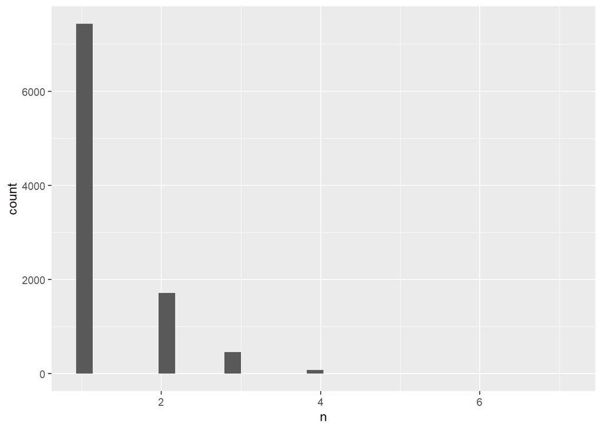

```r
 ME_term_records %>%
  count(ABT_INMATE_ID, sort = TRUE) %>%
  ggplot(aes(n)) +
  geom_histogram()
```

Of those 9,694 observations, 367 have been admitted because they violated their parole. Although it can happen more than once, most inmates have returned to prison only once for violating parole.

```r
 ME_term_records %>%
   filter(ADMTYPE == "(2) Parole return/revocation") %>%
   count(ABT_INMATE_ID, sort = TRUE) %>%
  head()
```

```
##         ABT_INMATE_ID n
## 1 A232021000000000048 5
## 2 A232021000000001675 3
## 3 A232021000000007107 3
## 4 A232021000000000392 2
## 5 A232021000000000399 2
## 6 A232021000000000462 2
```

## What are the distribution of sentences served in Maine ?

Here, I created a variable to get the exact sentence length by subtracting the release yr from admin year. I created another variable to get the exact maximum sentence length by using the largest value in the range given in the code book. I also created a variable to see if prisoners were getting released way before the max sentence length (certainty of sentences was one of the reasons Maine implemented Parole). I also created a variable including whether that inmate is a repeat offender or not. 22.35% of all inmates are repeat offenders.

```r
me_analysis <- ME_term_records %>%
  select(-(8:10)) %>%
  mutate(exact_time_served = RELEASEYR - ADMITYR,
         exact_maxsentlgth = case_when(
           SENTLGTH == "(0) < 1 year" ~ 1,
           SENTLGTH == "(1) 1-1.9 years" ~ 1.9,
           SENTLGTH == "(2) 2-4.9 years" ~ 4.9,
           SENTLGTH == "(3) 5-9.9 years" ~ 9.9,
           SENTLGTH == "(4) 10-24.9 years" ~ 24.9)) %>%
  mutate(released_early = exact_maxsentlgth - exact_time_served)

ro <- me_analysis %>%
  count(ABT_INMATE_ID, sort = TRUE) %>%
  mutate(Repeat_Offender = case_when(
    n > 1 ~ "Yes",
    TRUE ~ "No"
  ))

me_analysis <- me_analysis %>%
  full_join(ro, by = "ABT_INMATE_ID")


colnames(me_analysis)[19] = "In_Datasetx?"
```

As we can see the histogram below, most prisoners are serving 2 years or less in prison (71.2%) and not many are serving more than that (15.1%). A time served of 0, indicates that they were released within the same year and served only less than a year sentence (14.8% of inmates). Due to missing values in either the release or admission year, we don’t know the prison sentences of about 13.6% of the inmates.

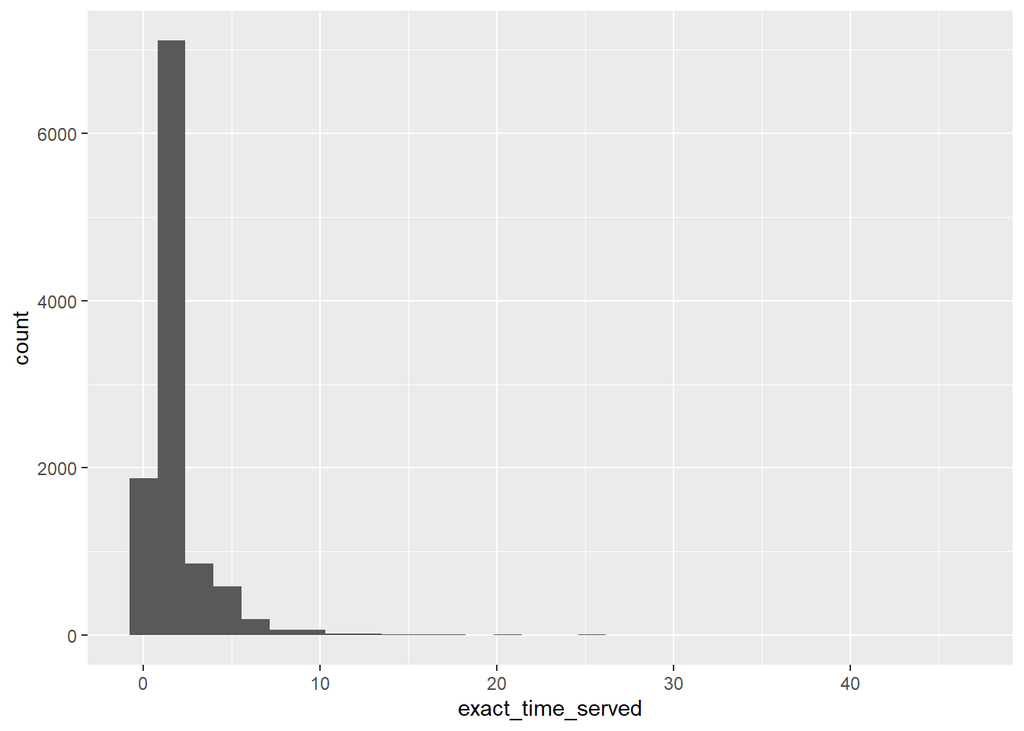

```r
me_analysis %>%
  ggplot(aes(exact_time_served)) + geom_histogram()
```

Because it’s skewed to the right (highest sentences: 30,35,36,37,40,45,46) I created another logged plot below

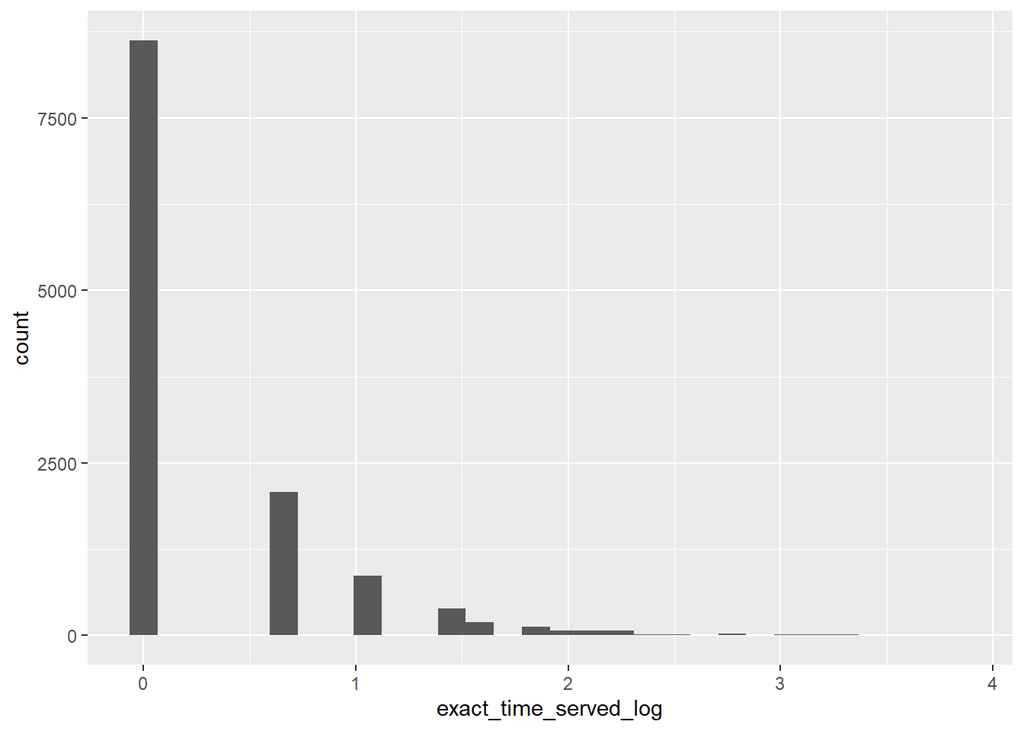

```r
me_analysis %>%
  mutate(exact_time_served_log = case_when(
    exact_time_served != 0 ~ log(exact_time_served),
    TRUE ~ 0
  )) %>%
  ggplot(aes(exact_time_served_log)) + geom_histogram()
```

There’s no data for Maine from 2002 - 2012 in the prison releases dataset. Sidenote, I don’t know what to do with respective to time in my analysis… (RPTYEAR = the year data was submitted to NCRP)

## What percentage of prisoners are already getting released before the maximum length given and what’s the distribtuion of that?

Keep in mind that the maximum sentence lengths were given in a range, so many of these are overestimates. However, I can guess on this graph that many are being released about 2-3 years earlier, which could be due to good time? (factors such as year, whether it’s conditional or unconditional release, and offense are also important to consider)

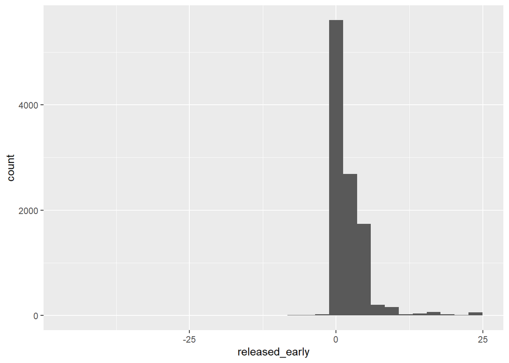

```r
me_analysis %>%
  ggplot(aes(released_early)) +
  geom_histogram()
```

Here, I use reference @tml1975 to classify the terms. Since there’s no way to combine the data frames, but I calculated the average sentence length per crime type. I look at the distribution of each of the classifications given in the dataset, and it aligned with the Maine classifications…

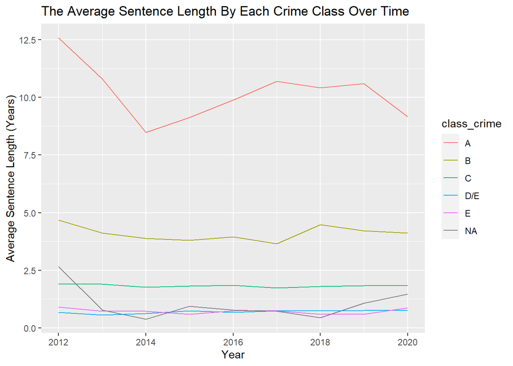

```r
me_analysis <- me_analysis %>% #classified based on reference @tml1975
  mutate(class_crime = case_when(
    SENTLGTH == "(0) < 1 year" ~ "E",
    SENTLGTH == "(3) 5-9.9 years" ~ "B",
    SENTLGTH == "(4) 10-24.9 years" ~ "A",
    SENTLGTH == "(5) >=25 years" ~ "A",  #murder to be exact
    SENTLGTH == "(6) Life, LWOP, Life plus additional years, Death" ~ "A",
    SENTLGTH == "(1) 1-1.9 years" & TIMESRVD == "(3) 5-9.9 years" ~ "B", #timeserved > maxsentlgth so classified based on time served for simplicity
    SENTLGTH == "(2) 2-4.9 years" & TIMESRVD == "(3) 5-9.9 years" ~ "B",
    SENTLGTH == "(1) 1-1.9 years" & TIMESRVD == "(4) >=10 years" ~ "B", #1 obs, time served = 10, not > 10 so class B
    SENTLGTH == "(2) 2-4.9 years" & TIMESRVD == "(4) >=10 years" ~ "A",
    SENTLGTH == "(1) 1-1.9 years" & TIMESRVD == "(0) < 1 year" ~ "D/E",
    SENTLGTH == "(2) 2-4.9 years" & TIMESRVD == "(0) < 1 year" ~ "D/E",
    SENTLGTH == "(1) 1-1.9 years" & TIMESRVD == "(1) 1-1.9 years" ~ "C",
    SENTLGTH == "(2) 2-4.9 years" & TIMESRVD == "(1) 1-1.9 years" ~ "C",
    SENTLGTH == "(1) 1-1.9 years" & TIMESRVD == "(2) 2-4.9 years" ~ "C",
    SENTLGTH == "(2) 2-4.9 years" & TIMESRVD == "(2) 2-4.9 years" ~ "C"
  ))

#for the rest of the values we either don't know the time served or the maximum sentlgth or both so it's NA, can run code below to see
# %>% filter(is.na(class_crime)) %>%
#   count(SENTLGTH, TIMESRVD)



me_analysis %>%
  group_by(class_crime, RELEASEYR) %>%
  summarize(avg_sentlgth = mean(exact_time_served)) %>%
  ggplot(aes(RELEASEYR, avg_sentlgth, color = class_crime)) +
  geom_line() +
  labs(title = "The Average Sentence Length By Each Crime Class Over Time", x ="Year", y = "Average Sentence Length (Years)")
```

## What percentage of prisoners are eligible for good time credits?

Note that there can be way more observation because we had to use the NCRP’s general categories which we don’t know the criteria for. However, for prisoners convicted of sexual assault or murder (1375 or about 10.9% of our data) who have full credits of 5 days per month throughout a prison sentence, the release date (or the actual time served) is about ~83.5% of the maximum sentence given by a judge.

Keep in mind that 8% has NA - missing

Formula: (12 * time served) * (5 days per month) = good time credits available in days

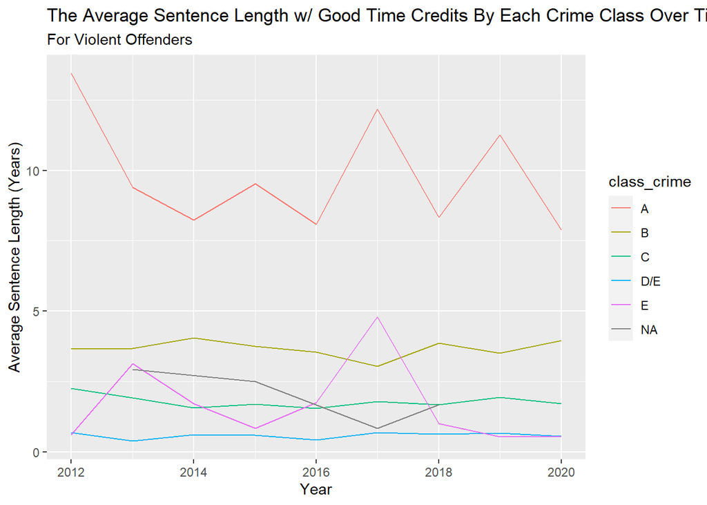

```r
df1 <- me_analysis %>%
  filter(OFFDETAIL == "(01) Murder (including non-negligent manslaughter)" | OFFDETAIL == "(03) Rape/sexual assault") %>%
  mutate(Good_time_credits = (12 * exact_time_served) * 5,  #the amt of good time credits they have in days
         gtc_exact_time_served = (( (365 * exact_time_served) - Good_time_credits ) / (365)), # using time served to represent max sentence length, this is the projected sentence length with good time credits in years
         gtc_exact_maxsentlgth = (( (365 * exact_maxsentlgth) - Good_time_credits ) / (365)))  # using max sent. length range given to represent  max sentence length, this is the projected sentence length with good time credits in years


df1 %>% #violent offenders
  mutate(class_crime = case_when(
    SENTLGTH == "(0) < 1 year" ~ "E",
    SENTLGTH == "(3) 5-9.9 years" ~ "B",
    SENTLGTH == "(4) 10-24.9 years" ~ "A",
    SENTLGTH == "(5) >=25 years" ~ "A",  #murder to be exact
    SENTLGTH == "(6) Life, LWOP, Life plus additional years, Death" ~ "A",
    SENTLGTH == "(1) 1-1.9 years" & TIMESRVD == "(3) 5-9.9 years" ~ "B", #timeserved > maxsentlgth so classified based on time served for simplicity
    SENTLGTH == "(2) 2-4.9 years" & TIMESRVD == "(3) 5-9.9 years" ~ "B",
    SENTLGTH == "(1) 1-1.9 years" & TIMESRVD == "(4) >=10 years" ~ "B", #1 obs, time served = 10, not > 10 so class B
    SENTLGTH == "(2) 2-4.9 years" & TIMESRVD == "(4) >=10 years" ~ "A",
    SENTLGTH == "(1) 1-1.9 years" & TIMESRVD == "(0) < 1 year" ~ "D/E",
    SENTLGTH == "(2) 2-4.9 years" & TIMESRVD == "(0) < 1 year" ~ "D/E",
    SENTLGTH == "(1) 1-1.9 years" & TIMESRVD == "(1) 1-1.9 years" ~ "C",
    SENTLGTH == "(2) 2-4.9 years" & TIMESRVD == "(1) 1-1.9 years" ~ "C",
    SENTLGTH == "(1) 1-1.9 years" & TIMESRVD == "(2) 2-4.9 years" ~ "C",
    SENTLGTH == "(2) 2-4.9 years" & TIMESRVD == "(2) 2-4.9 years" ~ "C"
  )) %>%
  group_by(class_crime, RELEASEYR) %>%
  summarize(avg_sentlgth_gtc = mean(gtc_exact_time_served)) %>%
  ggplot(aes(RELEASEYR, avg_sentlgth_gtc, color = class_crime)) +
  geom_line() +
  labs(title = "The Average Sentence Length w/ Good Time Credits By Each Crime Class Over Time", subtitle = "For Violent Offenders", x = "Year", y = "Average Sentence Length (Years)")
```

For all other prisoners (89.1% of our data), who have full credits of up to 9 days of good time credits through their prison sentence, the release date (or the actual time served) s about ~70% of the maximum sentence given by a judge

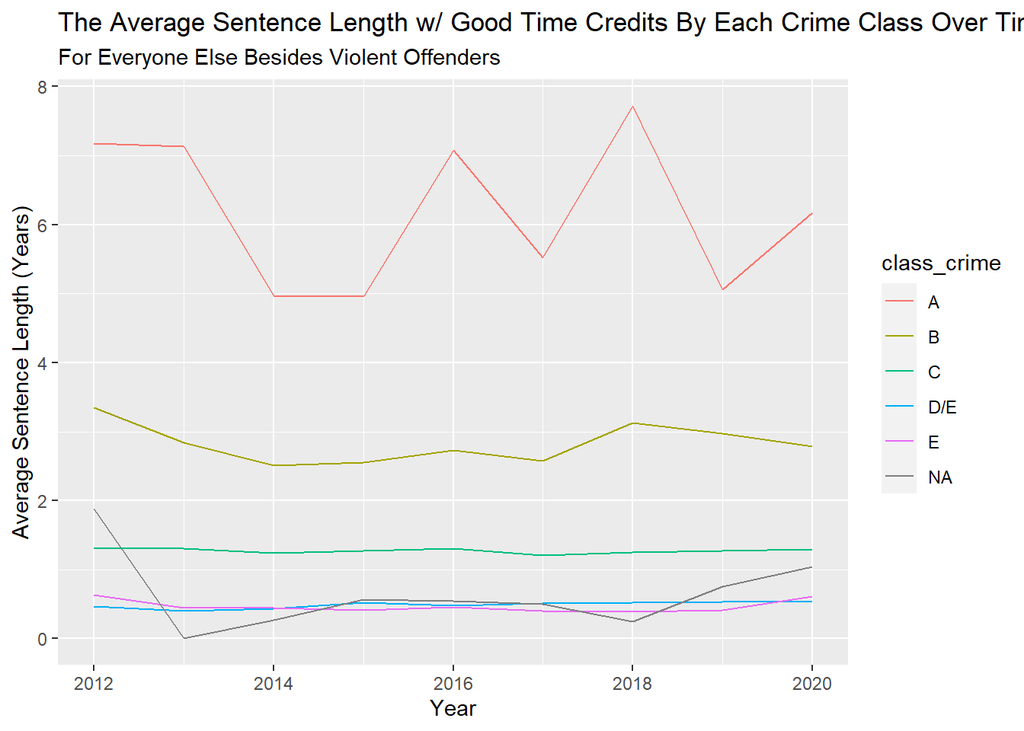

```r
# Formula: (12 * time served) * (9 days per month) = good time credits available in days


df2 <- me_analysis %>%
  filter(OFFDETAIL != "(01) Murder (including non-negligent manslaughter)" & OFFDETAIL != "(03) Rape/sexual assault" | is.na(OFFDETAIL)) %>%
  mutate(Good_time_credits = (12 * exact_time_served) * 9, #the amt of good time credits they have in days
         gtc_exact_time_served = (( (365 * exact_time_served) - Good_time_credits ) / (365)), # using time served to represent max sentence length, this is the projected sentence length with good time credits in years
         gtc_exact_maxsentlgth = (( (365 * exact_maxsentlgth) - Good_time_credits ) / (365)))  # using max sent. length range given to represent  max sentence length, this is the projected sentence length with good time credits in years

df2 %>% #everyone else
  mutate(class_crime = case_when(
    SENTLGTH == "(0) < 1 year" ~ "E",
    SENTLGTH == "(3) 5-9.9 years" ~ "B",
    SENTLGTH == "(4) 10-24.9 years" ~ "A",
    SENTLGTH == "(5) >=25 years" ~ "A",  #murder to be exact
    SENTLGTH == "(6) Life, LWOP, Life plus additional years, Death" ~ "A",
    SENTLGTH == "(1) 1-1.9 years" & TIMESRVD == "(3) 5-9.9 years" ~ "B", #timeserved > maxsentlgth so classified based on time served for simplicity
    SENTLGTH == "(2) 2-4.9 years" & TIMESRVD == "(3) 5-9.9 years" ~ "B",
    SENTLGTH == "(1) 1-1.9 years" & TIMESRVD == "(4) >=10 years" ~ "B", #1 obs, time served = 10, not > 10 so class B
    SENTLGTH == "(2) 2-4.9 years" & TIMESRVD == "(4) >=10 years" ~ "A",
    SENTLGTH == "(1) 1-1.9 years" & TIMESRVD == "(0) < 1 year" ~ "D/E",
    SENTLGTH == "(2) 2-4.9 years" & TIMESRVD == "(0) < 1 year" ~ "D/E",
    SENTLGTH == "(1) 1-1.9 years" & TIMESRVD == "(1) 1-1.9 years" ~ "C",
    SENTLGTH == "(2) 2-4.9 years" & TIMESRVD == "(1) 1-1.9 years" ~ "C",
    SENTLGTH == "(1) 1-1.9 years" & TIMESRVD == "(2) 2-4.9 years" ~ "C",
    SENTLGTH == "(2) 2-4.9 years" & TIMESRVD == "(2) 2-4.9 years" ~ "C"
  )) %>%
  group_by(class_crime, RELEASEYR) %>%
  summarize(avg_sentlgth_gtc = mean(gtc_exact_time_served)) %>%
  ggplot(aes(RELEASEYR, avg_sentlgth_gtc, color = class_crime)) +
  geom_line() +
  labs(title = "The Average Sentence Length w/ Good Time Credits By Each Crime Class Over Time", subtitle = "For Everyone Else Besides Violent Offenders", x = "Year", y = "Average Sentence Length (Years)")
```

TO DO:

1. look at how other studies checked for certainty in Maine, look over how other studies did a cost benefit analysis and what you can do, then
2. calculate cost per prisoner…
3. look at the prison lenghts in Maine, classify them by crime and compare figure out the “minimum” in Maine 4.impose vermont and Wyoming model
4. calculate cost per prisoner
5. difference in sentence legnth as well and the certainty

maybe so an analysis of maine sentence lengths to check for “certainty” (based on the offense!) and then after imposing wyoming’s and Vermont’s paorle model, check for any changes in “certainity” of sentences (think about minimum vs. maximum sentences)

# Basic Summary Statistics/EDA - National Prisoner Statistics, [United States], 1978-2021 (ICPSR 38555)

```r
#VARIABLES OF INTEREST: TOTAL IN CUSTODY, CONDITIONAL RELEASE PROBATIONS, DESIGN CAPACITY, DISCRETIONARY PAROLE (RLCODPF/RLCODPM), FEDERAL OR OTHER STATES' FACILITIES SOLELY TO EASE CROWDING, FEMALE FROM 1991 - 2000 (FACROWDF/FACROWDM),(LFCROWDF/LFCROWDM) LOCAL FACILITIES SOLELY TO EASE PRISON CROWDING, FEMALE (1978-2000), LFCRSTF/LFCRSTF)LOCAL FACILITIES SOLELY TO EASE PRISON CROWDING, FEMALE (PRE-1978), (CAPOPM/ CAPOPF) OPERATIONAL CAPACITY, MALE (1999-CURRENT),

library(skimr)
me_prison_stats71 <- read.spss("C:/Users/kevin chen/OneDrive - bates.edu/Bates Parole Thesis/38555-0001-Data.sav", to.data.frame=TRUE) %>%
   filter(STATE == "ME")
```

[figure not shown]

```r
me_prison_stats71 %>%
  ggplot() + geom_line(aes(x = me_prison_stats71$YEAR, y = as.numeric(levels(me_prison_stats71$PARNEWM))[me_prison_stats71$PARNEWM], col = "red")) + geom_line(aes(x = me_prison_stats71$YEAR, y = as.numeric(levels(me_prison_stats71$PARNEWF))[me_prison_stats71$PARNEWF], col = "blue")) + labs(x = "Year", y = "Parole Violators with a New Sentence", title = "The change in Parole Violators with a new sentence from 1978 to 2021", col = "Gender (B = M and R = F)")
```

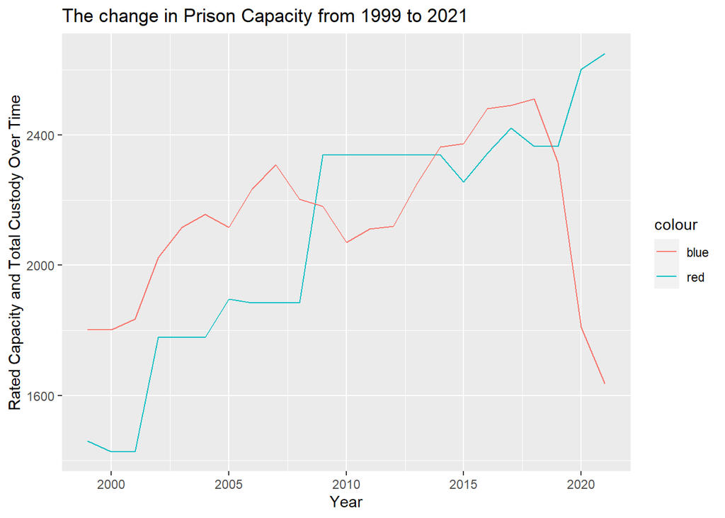

```r
# col 143 - rated capacity, Male, CAPRATEM
# col 11 - total under custody, males (1983-current) + col 12 (females), CUSTOTM + CUSTOTF
# have to filter for 1999 bc capacity doesn't have data until then

me_prison_stats71 %>%
  filter(YEAR >= 1999) %>%
  mutate(TUC = as.numeric(levels(CUSTOTM))[CUSTOTM] + as.numeric(levels(CUSTOTF))[CUSTOTM], TRC = as.numeric(levels(CAPRATEM))[CAPRATEM] + as.numeric(levels(CAPRATEF))[CAPRATEF]) %>%
  ggplot() + geom_line(aes(x = YEAR, y = TRC, col = "red")) + geom_line(aes(x = YEAR, y = TUC, col = "blue")) + labs(x = "Year", y = "Rated Capacity and Total Custody Over Time", title = "The change in Prison Capacity from 1999 to 2021")
```

# Basic Summary Statistics/EDA - Annual Survey of Jails, 2021 (ICPSR 38573)